# TAP 03 (Report)

Author

291928

```r
library(tidyverse)
library(dplyr)
library(ggplot2)
library(datawizard)
library(broom)
library(ggfortify)
library(patchwork)
library(kableExtra)

# load the data here

stats_tib <- here::here("/cloud/project/data/tap_learning_statistics.csv") |>
  readr::read_csv()

# Changing community from a character variable to a factor variable
# Releveling the community factor in this way 1- None 2- Online 3- In person


stats_tib <- stats_tib |>
  dplyr::mutate(
     community = forcats::fct_relevel(community, "None" , "Online" , "In person")
  )

# changing university as a character into a numerical variable

stats_tib <- stats_tib |>
  dplyr::mutate(
    uni = forcats::fct_relevel(uni, paste("University", 1:20))
  )
```

# Analysis Plan

Regarding the provided hypotheses, it is assumed that students’ performance on their statistics exam (`stats_exam`) will be predicted by their statistics anxiety (`stats_anxiety`) while this relationship is adjusted for general levels of anxiety (`gen_anxiety`). To test this, statistics anxiety (`stats_anxiety`) and general anxiety (`gen_anxiety`) will be added to this model as the predictor variable and covariate, respectively.

However, it is hypothesized that the relationship between statistics anxiety (`stats_anxiety`) and students’ performance on the statistics exam (`stats_exam`) will be moderated by the community (`community`) to which students were assigned, and being in a learning community will reduce the relationship between statistics anxiety and students’ performance. To test the moderating effect of the community (`community`) on the relationship between statistics anxiety (`stats_anxiety`) and students’ performance (`stats_exam`), the interaction effect between the predictor (`stats_anxiety`) and moderator (`community`) should be included in the model ($\text{statistics anxiety} \ \times \ \text{community}$). Additionally, to test the second part of the moderation-related hypothesis and to specify the moderation effect, two contrasts should be added to the model including:

$\text{Contrast}_1$: To assess whether the relationship between statistics anxiety (stats_anxiety) and students’ performance in statistics exam (`stats_exam`) is weaker among students who were assigned to a peer community compared to those not.

$\text{Contrast}_2$: To assess whether the relationship between statistics anxiety (`stats_anxiety`) and students’ performance in statistics exam (`stats_exam`) is weaker among students who were assigned to the In-person community compared to those assigned to the Online community.

Finally, it is hypothesized that the overall performance on the statistics exam (`stats_exam`), and the relationship between statistics anxiety (`stats_anxiety`) and students’ performance vary across 20 universities. So, in our model, performance on the statistics exam (the intercept), and the slope for the relationship between statistics anxiety and students’ performance should be treated as random effects. Since we are assuming that intercepts, and slopes for the relationship between statistics anxiety and students’ performance should be treated as random effects, the data should be assumed as a hierarchical data with multiple level (student level and university level). This multilevel structure for data is due to the fact that that students are nested within universities, and students in the same university will perform more simillarly compared to students from different universities. Consequently, a multilevel model with random effects (instead of OLS model with fixed effects) should be implemented. Hence, to test the following hypotheses:

- H<sub>1</sub>: Adjusting for general levels of anxiety (`gen_anxiety`), performance on the statistics assignment (`stats_exam`) will be predicted by statistics anxiety (`stats_anxiety`), but this effect will be moderated by the community to which the student was assigned (`community`). Being in a learning community should reduce the relationship between statistics anxiety and statistics performance. Specifially, the relationship between statistics anxiety and statistics performance will be weaker in (1) those assigned to a peer community compared to those not; (2) those assigned to an in person communities compared to those assigned to an online communities. Overall levels of performance on the statistics assignment, and the relationship between statistics anxiety and performance are expected to vary across the 20 universities. As well as testing the hypotheses above, the research team want estimates of the variability in the intercept and slope of statistics anxiety across universities.

The following model will be fitted:

$$Stats \ Exam = \ [\beta_0 \ + \ \beta_1General \ anxiety_{ij} \ + \ \beta_2Statistics \ anxiety_{ij} \ + \ \beta_3Contrast1_{ij} \ + \ \beta_4Contrast2_{ij}$$

$$+ \ \beta_5(Statistics \ anxiety \ \times Contrast1)_{ij} \ + \ \beta_6(Statistics \ anxiety \ \times Contrast2)_{ij}]$$

$$+ \ [v_{0j} \ + \ v_{1j}Statistics \ anxiety_{ij} \ + \ \epsilon_{ij}]$$

Data will be summarized and visualized as follows:

- Descriptive statistics (mean, standard deviation, inter-quartile range, skewness, kurtosis, and confidence intervals) of statistics anxiety (`stats_anxiety`), general anxiety (`gen_anxiety`), and performance on statistical module (`stats_exam`) will be provided to explore distributional properties and central tendencies related to data.
- Box plots of general anxiety (`gen_anxiety`), statistics anxiety (`stats_anxiety`), and students’ performance on the statistics module (`stats_exam`) to explore their distribution pattern and outliers.
- Matrix of scatter plots, distribution plots, and correlation value among numerical variables will be plotted to check the relationship between these variables and their distributional pattern.
- Descriptive statistics (mean, standard deviation, inter-quartile range, skewness, kurtosis, and confidence intervals) of general anxiety (`gen_anxiety`), statistics anxiety (`stats_anxiety`), and performance on statistical module (`stats_exam`) grouped by their community group will be presented to illustrate the overall status of central tendencies and distributional properties regarding students’ performance, students’ statistics anxiety, and general anxiety in different community groups.
- Violin plots and mean of students’ performance on statistics exam (`stats_exam`) (y-axis) according to their community group (`community`) (x-axis) to show the distribution pattern of students’ performance regarding their community group.
- Correlation matrix for the relationship between statistics anxiety (`stats_anxiety`) and students’ performance on the statistics exam (`stats_exam`) grouped by their community group (`community`) to provide some initial information regarding the correlation of this relationship in different groups (None, Online, and In-person).
- Scatter plot of statistics anxiety (`stats_anxiety`) (x-axis) against students’ performance (`stats_exam`) (y-axis) grouped by their community group (`community`) to see the trend of the relationship according to students’ community group which gives initial information to find insight about whether the moderation effect is reasonable or not.
- Simple slopes will be defined and plotted to find the trend of the relationship between statistics anxiety (`stats_anxiety`) and students’ performance (`stats_exam`) on different levels of community (`community`). This result will help to find how different levels of community will moderate the relationship between statistics anxiety and students’ performance.
- Descriptive statistics (mean, standard deviation, inter-quartile range, skewness, kurtosis, and confidence intervals) of statistics anxiety (`stats_anxiety`) and performance on statistical module (`stats_exam`) grouped by their university will be presented to illustrate the overall status of central tendencies and distributional properties regarding students’ performance and students’ statistics anxiety in different universities.
- Scatter plots for the relationship between statistics anxiety (`stats_anxiety`) and students’ performance on their statistics exam (`stats_exam`) split by the university which they were assigned. These plots provide overall insight about the variation in the intercept and the relationship between statistics anxiety and students’ performance (slope) across different universities, which help for justifying the use of multilevel model with random effects.
- Plotting the distribution of results from fitting fixed models (assuming pooled data) in individual universities. These plots can provide insight regarding the distribution of the intercept and slope for the relationship between statistics anxiety (`stats_anxiety`) and students’ performance on their statistics exam (`stats_exam`) which will be helpful for defining the intercept and the slope for the relationship between statistics anxiety and students’ performance as random effects or fixed effects.

The multilevel model will be fitted. To check the generalizability of our results and to ensure that the utilized model is proper, assumptions of a multilevel model should be checked as follows (most of the assumptions align with the assumptions of the general linear model) :

- **Linearity:** The relationship between predictor variables (general anxiety (`gen_anxiety`) and statistics anxiety (`stats_anxiety`)) and outcome variables (students’ performance on the statistics exam (`stats_exam`)) should be linear. This assumption will be evaluated using a scatter plot of fitted values (x-axis) against the residual values (y-axis), which will be used as evidence for linearity. To meet this assumption the line in this scatter plot should be flat and horizontal.
- **Homoscedasticity**: The variance of the model’s level one errors should be consistent across all levels of the predictor variable. In practice, residuals are used as proxies to assess this assumption. A scatter plot of fitted values (x-axis) against residuals (y-axis) will be used to evaluate homoscedasticity. To meet this assumption, the pattern of distribution should be random without following a non-random pattern (such as funnel-shaped patterns).
- **Independence**: The model errors should be independent of one another; that is, the error for one observation should not provide information about the error for another observation. To check this assumption, a scatter plot of case number (x-axis) against standardized residual values (y-axis) would be used. Residuals should be randomly scattered over the length of the x-axis. However, this assumption is not a problem for a multilevel model since it is possible to model that into our multilevel model. In fact, assuming a model as a multilevel model would violate the assumption of independence; hence, there is a need to model that into our model.
- **Normality of Model Errors:** Normality of model’s level one errors should be assessed. Since the sample size is large enough, the normality of sampling distribution due to the central limit theorem (CLT) is assumed without further checking. While due to the large sample size ($n = 1576$) normality of model errors is reasonable, a q-q plot of standard residuals (as a tangible proxy for model error) will be utilized for double-checking.
- **Normality of Random Effects:** In multilevel models, in addition to previous assumptions, random effects including intercepts and slopes should be normally distributed with a mean of zero. To assess this assumption two q-q plots would be plotted for the intercept and the slope for the relationship between statistics anxiety (`stats_anxiety`) and students’ performance (`stats_exam`) respectively. However, multilevel models are generally robust to minor deviations from normality. Therefore, unless substantial deviations from the normality line are observed in the q-q plots, the assumption of normality for the random effects will be met.

Contingency plans if any of the assumptions are not met:

- **Linearity:** If this assumption is violated, two alternative approaches are possible including fitting a non-linear model and transforming data to achieve linearity.
- **Homoscedasticity:** If this assumption is violated, two alternative approaches are possible including data transformation, modeling different types of variances, and reevaluating the model for covariances and their structure, interactions, fixed effects, and random effects can handle the situation of heteroscedasticity.
- **Independence:** If this assumption is violated, it is possible to model the dependency between data.
- **Normality of Model Errors and Random Effects:** If this assumption is violated, a robust model could be applied that is less sensitive to normality.

Initially, a pooled model (without considering the hierarchical structure of data and hypothesis) will be fitted to provide us with initial insight regarding the relationship between variables. Then, this pooled model will be fitted for each university and distribution of results for fitting this model across universities will be visualized in tables and plots to find out whether intercepts and slopes should be treated as random effects or fixed effects. If intercepts and slopes vary across universities, the data will be considered hierarchical, and a multilevel model will be fitted with intercepts and slope of statistics anxiety as random effects. Then, fixed effects (main effects and interaction effects) of the multilevel model will be analyzed using $\alpha=0.05$ as a significance criterion. Overall, the $p-value$ solely is not a reliable source of making final conclusions, specifically in multilevel models (especially with our large sample size $n =1576$); hence, to ensure the validity of the $p-value$, confidence intervals will be checked to ensure that they are not crossing zero, and the real-world meaning of beta estimations will be discussed. Next, random effects will be analzed to find standard deviations for intercepts and slope (statistics anxiety (`stats_anxiety`)). Finally, if the assumptions are met, the aforementioned multilevel method will be fitted and results will be interpretable and generalizable, otherwise, there is a need to fit a robust model (for normality issues) or reevaluating our model in accordance to the violated assumption.

# Coding

## Summary statistics and data visualization

```r
# Descriptive statistics of statistics anxiety
# Descriptive statistics of general anxiety
# Descriptive statistics of students' performance


descriptive_variables <- stats_tib |>
  datawizard::describe_distribution(
    c(stats_anxiety , gen_anxiety , stats_exam),
    range = FALSE
    ) |>
    knitr::kable(digits = 3)


# Box plot of statistics anxiety

box_stats_anxiety <- ggplot(stats_tib, aes(stats_anxiety)) +
  geom_boxplot(fill = "#ff7f00") +
  labs(x = "Statistics Anxiety") +
  theme_bw()

# Box plot of general anxiety

box_general_anxiety <- ggplot(stats_tib, aes(gen_anxiety)) +
  geom_boxplot(fill = "#ff7f00") +
  labs(x = "General Anxiety") +
  theme_bw()

# Box plot of students' performance

box_stats_exam <- ggplot(stats_tib, aes(stats_exam)) +
  geom_boxplot(fill = "#ff7f00") +
  labs(x = "Students' Performance") +
  theme_bw()

# Descriptive statistics of statistics anxiety grouped by community group
# Descriptive statistics of general anxiety grouped by community group
# Descriptive statistics of students' performance grouped by community group

descriptive_variables_grouped <- stats_tib |>
  group_by(community) |>
  datawizard::describe_distribution(
    c(stats_anxiety , gen_anxiety , stats_exam),
    range = FALSE
    ) |>
    knitr::kable(digits = 3)

# Violin plot of statistics anxiety grouped by community group

violin_stats_anxiety <- ggplot(stats_tib, aes(community, stats_anxiety , color = community)) +
  geom_violin() +
  stat_summary(fun = mean , geom = "point") +
  stat_summary(fun.data = mean_cl_normal , geom = "errorbar") +
  labs(x = "Community" , y = "Statistics Anxiety") +
  theme_bw()

# Violin plot of general anxiety grouped by community group

violin_stats_anxiety <- ggplot(stats_tib, aes(community, gen_anxiety , color = community)) +
  geom_violin() +
  stat_summary(fun = mean , geom = "point") +
  stat_summary(fun.data = mean_cl_normal , geom = "errorbar") +
  labs(x = "Community" , y = "General Anxiety") +
  theme_bw()

# Violin plot of students' performance grouped by community group

violin_stats_exam <- ggplot(stats_tib, aes(community, stats_exam , color = community)) +
  geom_violin() +
  stat_summary(fun = mean , geom = "point") +
  stat_summary(fun.data = mean_cl_normal , geom = "errorbar") +
  labs(x = "Community" , y = "Students' Performance") +
  theme_bw()

# Correlation matrix between statistics anxiety and students' performance
# grouped by community group

matrix_cor_community <- stats_tib |>
  group_by(community) |>
  summarise(correlation = cor(stats_anxiety , stats_exam)) |>
  knitr::kable(digits = 3)

# Plotting a matrix of scatter plots, correlations, and distribution

desc_summary_matrix <- GGally::ggscatmat(stats_tib, columns = c("stats_anxiety" ,
                                                                "gen_anxiety" ,
                                                                "stats_exam"))

# Scatter plot of the statistics anxiety against students' performance
# grouped by community group

community_cor_scatter <- ggplot(stats_tib, aes(stats_anxiety , stats_exam, color = community)) +
  geom_point(alpha = 0.4) +
  geom_smooth(method = "lm") +
  labs(x = "Statistics Anxiety" , y = "Students' Performance") +
  theme_bw()

# Descriptive statistics of statistics anxiety grouped by universities
# Descriptive statistics of students' performance grouped by universities

descriptive_variables_grouped_uni <- stats_tib |>
  group_by(uni) |>
  datawizard::describe_distribution(
    c(stats_anxiety , stats_exam) ,
    range = FALSE) |>
  knitr::kable(digits = 3)

# Scatter plot for the relationship between statistics anxiety and students' performance split by universities

per_anx_uni <- ggplot2::ggplot(stats_tib, aes(stats_anxiety, stats_exam)) +
  geom_point(alpha = 0.2) +
  geom_smooth(method = "lm", linewidth = 0.5) +
  coord_cartesian(xlim = c(0, 65), ylim = c(0, 100)) +
  scale_y_continuous(breaks = seq(0, 100, 25)) +
  labs(x = "level of statistics anxiety", y = "performance on the exam") +
  facet_wrap(~ uni, ncol = 4) +
  theme_bw()
```

## Statistical model

```r
# Defining contrasts prior to checking the impact of differtent levels of community
# on the relationship between statistics anxiety and students' performance

# Contrast_1 for the difference between None and students in any community group

community_vs_none <- c(-2/3 , 1/3 , 1/3)

# Contrast_2 for the difference between Online and In person community groups

inperson_vs_online <- c(0 , -1/2 , 1/2)

# Adjusting coded contrasts to community

contrasts(stats_tib$community) <- cbind(community_vs_none , inperson_vs_online)

# Fitting a pooled model

pooled_fixed_model <- lm(stats_exam ~ gen_anxiety + stats_anxiety * community, data = stats_tib)

# Fitting the pooled model for each university after nesting these variables for unviersities

university_lms <- stats_tib  |>
  dplyr::arrange(uni) |>
  dplyr::group_by(uni)  |>
  tidyr::nest()  |>
  dplyr::mutate(
    model = purrr::map(.x = data, .f = \(uni_nest) lm(stats_exam ~ stats_anxiety * community + gen_anxiety, data = uni_nest)),
    coefs = purrr::map(model, broom::tidy, conf.int = TRUE)
    )

# Unnesting the estimates for university while ignoring data and model

uni_models_tib <- university_lms  |>
  dplyr::select(-c(data, model)) |>
  tidyr::unnest(coefs)

# Distribution plot of coeff estimates for the intercept and different slopes

random_distribution_plot <- ggplot(uni_models_tib, aes(estimate)) +
  geom_density() +
  facet_wrap(~term , scales = "free") +
  theme_bw()

# Fitting a multilevel model

final_random_model <- lmerTest::lmer(stats_exam ~ gen_anxiety + stats_anxiety * community + (stats_anxiety | uni),
                                     data = stats_tib,
                                     control = lme4::lmerControl(optimizer = "bobyqa"))

# Extracting F statistics regarding the fixed effect of predictors on the outcome variable

f_value_model <- anova(final_random_model) |>
  knitr::kable(digits = 3)

# Defining moderation effect according to the community group

simple_slopes_tib <- modelbased::estimate_slopes(final_random_model,
                            trend = "stats_anxiety",
                            by = "community",
                            ci = 0.95) |>
  knitr::kable(digits = 3)

# Plotting the moderation effect

moderation_plot <- interactions::interact_plot(
  model = final_random_model,
  pred = stats_anxiety,
  modx = community,
  interval = TRUE,
  x.label = "level of statistics anxiety",
  y.label = "performance on the statistics exam",
  legend.main = "assigned community"
  )

# Extracting beta estimates for fixed values

fixed_effect_estimates <- broom.mixed::tidy(final_random_model, conf.int = T , effects = "fixed") |>
  knitr::kable(digits = 3)


# Extracting standard deviations and slopes for random effects

random_effect_estimates <- broom.mixed::tidy(final_random_model, conf.int = T , effects = "ran_pars") |>
  knitr::kable(digits = 3)

# fitting a model only with random intercepts

final_random_model_intercept_only <- lmerTest::lmer(stats_exam ~ gen_anxiety + stats_anxiety * community + (1 | uni),
                                     data = stats_tib,
                                     control = lme4::lmerControl(optimizer = "bobyqa"))

# Defining the significance of adding statistics anxiety slope as a random effect

comparing_multilevel_models <- anova(final_random_model_intercept_only, final_random_model) |>
  knitr::kable(digits = 3)
```

## Model assumptions

```r
# Diagnostic plot for linearity assumption

linearity_assumption <- performance::check_model(final_random_model,
                                                   check = c("linearity"))

# Diagnostic plot for homogeneity assumption

homogeneity_assumption <- performance::check_model(final_random_model,
                                                   check = c("homogeneity"))

# Diagnostic plot for outliers

model_outliers <- performance::check_model(final_random_model,
                                           check = c("outliers"))

# Diagnostic plot for normality assumption

normality_assumption <- performance::check_model(final_random_model,
                                                 check = c("qq", "reqq"))
```

# Reports

## Summary statistics and data visualization

```r
descriptive_variables
```

Table 1

| Variable | Mean | SD | IQR | Skewness | Kurtosis | n | n_Missing |
| --- | --- | --- | --- | --- | --- | --- | --- |
| stats_anxiety | 39.944 | 6.909 | 9.00 | -0.081 | 0.218 | 1576 | 0 |
| gen_anxiety | 39.791 | 7.013 | 9.00 | 0.115 | -0.044 | 1576 | 0 |
| stats_exam | 49.845 | 15.817 | 21.75 | -0.132 | -0.297 | 1576 | 0 |

The provided Table 1 illustrates descriptive statistics of statistics anxiety (`stats_anxiety`) and students’ performance on statistics exam (`stats_exam`). Overall, the skewness and kurtosis for these three variables are small and near 0 which means they are close to the normal distribution. Also, no missing value exists in the data.

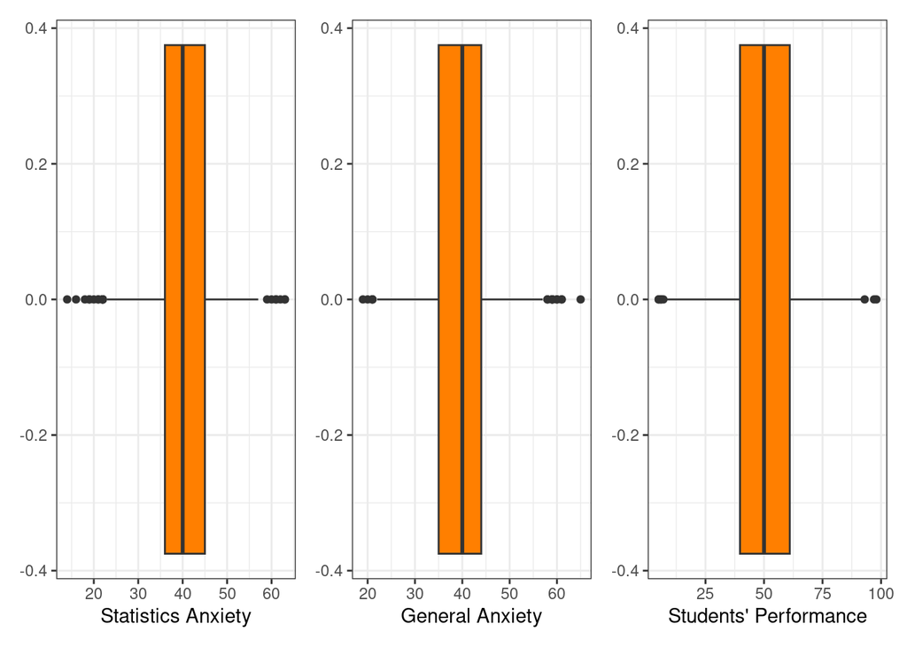

Figure 1

```r
box_stats_anxiety + box_general_anxiety + box_stats_exam
```

Illustrated box plots in Figure 1 show the inter-quartile range for statistics anxiety (`stats_anxiety`), general anxiety (`gen_anxiety`), and students’ performance on statistics exam (`stats_exam`). The mean for statistics anxiety and general anxiety are near 40 while the mean for students’ performance is near 50. As is illustrated, the interquartile range for statistics anxiety and students’ performance are between 35 and 45, and 38 and 62, respectively. As is presented the numbers of outlier cases compared to the large sample size (n = 1576) are pretty few. Consequently, it is reasonable to fit a model without much concern related to outlier cases. Also, the results of students’ performance, statistics anxiety, and general anxiety are in the range of 0-100 and 0-65, respectively, which means no obvious error in data entry can be seen for these two variables. Overall, there will be no outlier case removal in this analysis.

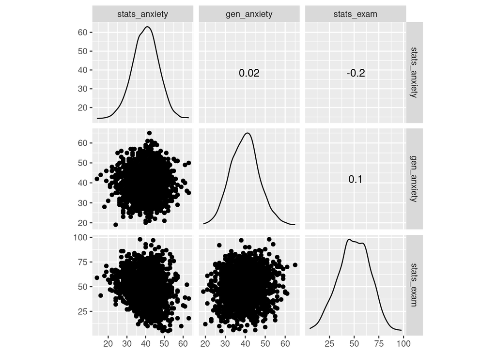

Figure 2

```r
desc_summary_matrix
```

Since various variables exist in the model, providing a summary of the relationship between these variables and the distribution of these variables can be insightful. As is presented in Figure 2, all three numerical variables are showing close to normal distribution. Also, in line with the first part of hypothesis which is “the performance on the statistics assignment (`stats_exam`) will be predicted by statistics anxiety (`stats_anxiety`)”, the scatter plot for the relationship between these two variables demonstrates a negative linear relationship and the correlation between these two variables is $-0.2$, which provide us with the initial clue for adding statistics anxiety in the model as a predictor of students’ performance.

```r
descriptive_variables_grouped
```

Table 2

| Variable | Mean | SD | IQR | Skewness | Kurtosis | n | n_Missing | .group |
| --- | --- | --- | --- | --- | --- | --- | --- | --- |
| stats_anxiety | 40.024 | 6.818 | 9.00 | -0.165 | 0.489 | 552 | 0 | community=None |
| gen_anxiety | 40.217 | 7.016 | 9.00 | -0.005 | -0.173 | 552 | 0 | community=None |
| stats_exam | 36.976 | 12.313 | 16.75 | -0.073 | -0.259 | 552 | 0 | community=None |
| stats_anxiety | 39.806 | 7.240 | 10.00 | -0.053 | 0.021 | 494 | 0 | community=Online |
| gen_anxiety | 39.617 | 6.910 | 9.00 | 0.095 | -0.035 | 494 | 0 | community=Online |
| stats_exam | 49.879 | 11.473 | 17.00 | -0.111 | -0.101 | 494 | 0 | community=Online |
| stats_anxiety | 39.989 | 6.693 | 8.00 | -0.014 | 0.150 | 530 | 0 | community=In person |
| gen_anxiety | 39.508 | 7.098 | 10.00 | 0.256 | 0.144 | 530 | 0 | community=In person |
| stats_exam | 63.217 | 10.599 | 15.00 | 0.127 | 0.000 | 530 | 0 | community=In person |

Table 2 illustrates that while statistics anxiety and general anxiety were consistent across different community groups (none, online, in person), students’ performance on their statistics exam varied significantly across these community groups ranging from approximately 37 in groups without peer community to roughly 63 in students in the in-person community group. These results can provide initial signs for the moderating role of the community (`community`) in the relationship between statistics anxiety and students’ performance on their statistics exam.

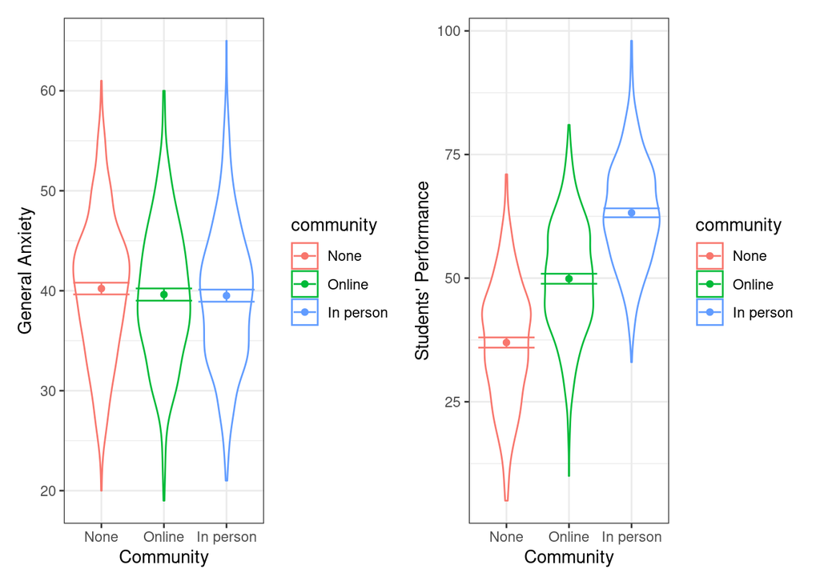

Figure 3

```r
violin_stats_anxiety + violin_stats_exam
```

```r
matrix_cor_community
```

Table 3

| community | correlation |
| --- | --- |
| None | -0.390 |
| Online | -0.318 |
| In person | -0.070 |

The provided Table 3 illustrates the relationship between statistics anxiety (`stats_anxiety`) and students’ performance (`stats_exam`) in three levels of community group (`community`) namely None, Online, and In-person. It is obvious that joining the online group decreased the aforementioned relationship. However, the difference between the In-person group and the other two groups is gigantic. Again, this information supports the idea of suggesting a community group (`community`) as a moderator while the impact of in-person community is much more significant compared to online community.

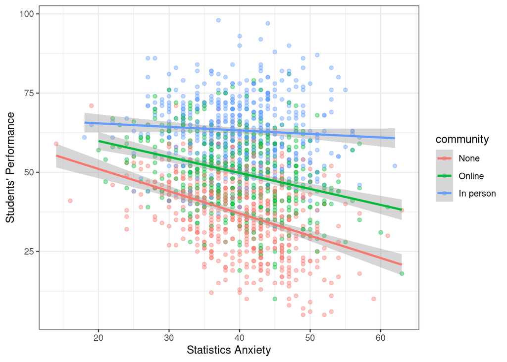

Figure 4

```r
community_cor_scatter
```

The scatter plots of the relationship between statistics anxiety (`stats_anxiety`) and students’ performance (`stats_exam`) grouped and divided by their community group (`community`) are presented in Figure 4 . While all lines show a negative slope, the slope for the In-person group is much smaller compared to other groups and it is near to a flat horizontal line. This closeness to a flat line for the In-person group demonstrates that the In-person group played the role of a shield in the relationship between statistics anxiety (`stats_anxiety`) and students’ performance (`stats_exam`) and reduced the impact of statistics anxiety on students’ performance. Additionally, the negative slope for the students who were assigned to no group (None) was sharper compared to students assigned to the online group.

```r
descriptive_variables_grouped_uni
```

Table 4

| Variable | Mean | SD | IQR | Skewness | Kurtosis | n | n_Missing | .group |
| --- | --- | --- | --- | --- | --- | --- | --- | --- |
| stats_anxiety | 39.344 | 6.903 | 10.75 | -0.110 | -0.531 | 64 | 0 | uni=University 1 |
| stats_exam | 60.844 | 12.207 | 20.75 | -0.128 | -0.514 | 64 | 0 | uni=University 1 |
| stats_anxiety | 40.341 | 6.314 | 7.00 | -0.072 | -0.317 | 91 | 0 | uni=University 2 |
| stats_exam | 52.549 | 14.142 | 24.00 | -0.162 | -0.973 | 91 | 0 | uni=University 2 |
| stats_anxiety | 41.386 | 7.461 | 10.00 | 0.074 | 0.313 | 70 | 0 | uni=University 3 |
| stats_exam | 44.857 | 16.300 | 23.50 | -0.273 | -0.516 | 70 | 0 | uni=University 3 |
| stats_anxiety | 40.500 | 7.576 | 9.00 | -0.077 | 0.782 | 102 | 0 | uni=University 4 |
| stats_exam | 59.392 | 13.077 | 19.00 | 0.242 | -0.171 | 102 | 0 | uni=University 4 |
| stats_anxiety | 40.265 | 6.654 | 8.50 | -1.052 | 1.346 | 49 | 0 | uni=University 5 |
| stats_exam | 48.102 | 13.591 | 21.50 | -0.626 | -0.551 | 49 | 0 | uni=University 5 |
| stats_anxiety | 40.599 | 6.758 | 9.00 | -0.098 | -0.002 | 137 | 0 | uni=University 6 |
| stats_exam | 53.642 | 12.948 | 21.00 | -0.057 | -0.798 | 137 | 0 | uni=University 6 |
| stats_anxiety | 38.565 | 7.012 | 10.25 | -0.149 | -0.439 | 62 | 0 | uni=University 7 |
| stats_exam | 52.000 | 14.642 | 23.50 | 0.180 | -0.748 | 62 | 0 | uni=University 7 |
| stats_anxiety | 39.966 | 6.527 | 7.00 | 0.180 | 1.154 | 29 | 0 | uni=University 8 |
| stats_exam | 50.138 | 12.789 | 18.50 | -0.063 | -0.563 | 29 | 0 | uni=University 8 |
| stats_anxiety | 39.671 | 7.318 | 10.00 | -0.047 | 1.116 | 76 | 0 | uni=University 9 |
| stats_exam | 44.066 | 15.238 | 24.75 | -0.218 | -0.570 | 76 | 0 | uni=University 9 |
| stats_anxiety | 40.246 | 5.952 | 7.50 | -0.166 | 0.603 | 69 | 0 | uni=University 10 |
| stats_exam | 38.145 | 14.435 | 21.50 | -0.071 | -0.413 | 69 | 0 | uni=University 10 |
| stats_anxiety | 39.833 | 7.670 | 10.00 | -0.247 | 0.273 | 162 | 0 | uni=University 11 |
| stats_exam | 43.772 | 15.607 | 21.25 | -0.286 | -0.450 | 162 | 0 | uni=University 11 |
| stats_anxiety | 41.111 | 5.145 | 6.75 | -0.873 | 0.653 | 72 | 0 | uni=University 12 |
| stats_exam | 52.528 | 14.232 | 20.50 | 0.010 | -0.540 | 72 | 0 | uni=University 12 |
| stats_anxiety | 38.807 | 6.576 | 8.75 | 0.422 | -0.016 | 88 | 0 | uni=University 13 |
| stats_exam | 41.795 | 13.194 | 19.75 | -0.033 | -0.636 | 88 | 0 | uni=University 13 |
| stats_anxiety | 40.408 | 6.646 | 9.00 | 0.255 | 0.120 | 130 | 0 | uni=University 14 |
| stats_exam | 39.692 | 15.201 | 25.00 | 0.091 | -0.922 | 130 | 0 | uni=University 14 |
| stats_anxiety | 39.846 | 7.014 | 11.00 | -0.020 | -0.743 | 52 | 0 | uni=University 15 |
| stats_exam | 67.173 | 13.936 | 18.75 | -0.100 | -0.591 | 52 | 0 | uni=University 15 |
| stats_anxiety | 38.447 | 7.572 | 10.00 | 0.172 | 0.138 | 114 | 0 | uni=University 16 |
| stats_exam | 50.386 | 13.276 | 17.25 | 0.063 | -0.049 | 114 | 0 | uni=University 16 |
| stats_anxiety | 39.931 | 6.600 | 7.75 | -0.228 | 0.890 | 72 | 0 | uni=University 17 |
| stats_exam | 56.847 | 13.118 | 19.50 | -0.108 | -0.575 | 72 | 0 | uni=University 17 |
| stats_anxiety | 41.024 | 7.104 | 9.50 | -0.123 | -0.262 | 42 | 0 | uni=University 18 |
| stats_exam | 49.738 | 12.057 | 16.50 | -0.416 | -0.394 | 42 | 0 | uni=University 18 |
| stats_anxiety | 39.267 | 6.092 | 7.75 | 0.057 | -0.417 | 60 | 0 | uni=University 19 |
| stats_exam | 60.683 | 14.183 | 21.75 | -0.149 | -0.489 | 60 | 0 | uni=University 19 |
| stats_anxiety | 39.057 | 7.340 | 11.00 | -0.101 | 0.215 | 35 | 0 | uni=University 20 |
| stats_exam | 44.171 | 12.035 | 18.00 | -0.281 | -0.327 | 35 | 0 | uni=University 20 |

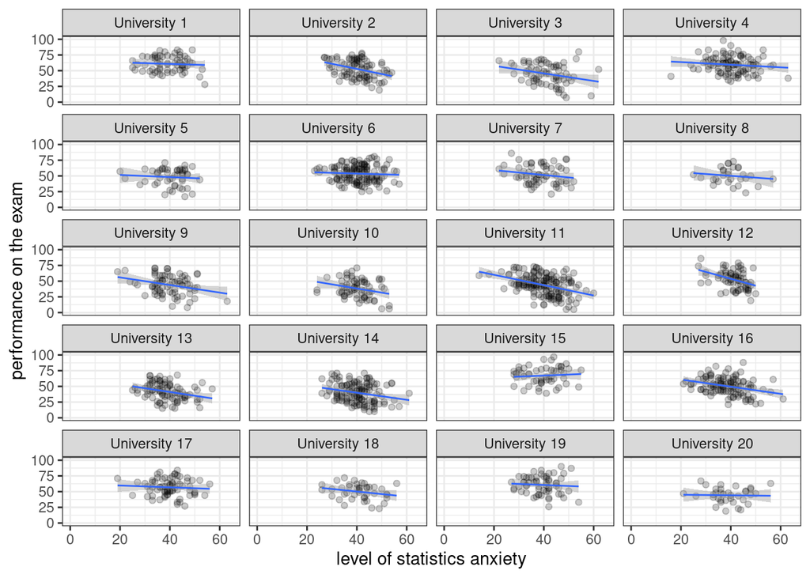

Figure 5

```r
per_anx_uni
```

In line with results and conclusions from the Table 4 , scatter plots for the relationship between statistics anxiety (`stats_anxiety`) and students’ performance on their statistics exam (`stats_exam`) across 20 universities. Figure 5 show that the intercept varies across universities (ranged from 67 to around 40). Additionally, it is observed that the slope for the relationship between statistics anxiety and students’ performance varies across universities too. While in many universities, a negative slope can be seen, in some other universities positive slopes (university number 15), smaller negative slopes (e.g. university number 4), and zero slopes (flat and horizontal lines) (e.g. university number 20) can be seen. Regarding these plots, it is reasonable to assume intercepts and slopes as random effects instead of fixed effects.

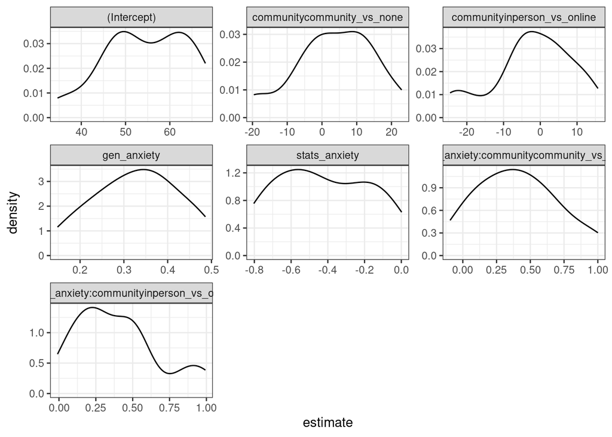

Figure 6

```r
random_distribution_plot
```

The provided plots in the Figure 6 , demonstrate the distribution of the parameter estimates resulting from fitting the fixed effect model on pooled data (not considering the hierarchical structure of data) in each individual university for all 20 universities. The pooled model is this:

$$Stats \ Exam = \ \beta_0 \ + \ \beta_1General \ anxiety_{i} \ + \ \beta_2Statistics \ anxiety_{i} \ + \ \beta_3Contrast1_{i} \ + \ \beta_4Contrast2_{i}$$

$$+ \ \beta_5(Statistics \ anxiety \ \times Contrast1)_{i} \ + \ \beta_6(Statistics \ anxiety \ \times Contrast2)_{i} \ + \epsilon_{i}$$

As is presented in Figure 6 , the intercept is centered around $50$. While the value of the intercept can range from $0$ to $100$ (the value of students’ scores on their statistics exam (`stats_exam`)), the bulk of the estimates range from $45$ to $65$. 20-point variation for a scale that theoretically can be between $0$ to $100$ is a significant variation in the intercept across different universities. This means that while a university’s intercept can be $45$, the intercept for another university can be $65$, which is a great difference for a 100-point scale (taking Figure 1 into account, this range is as big as the difference between the first and third quartile of students’ performance measure).

Overall, since the intercept and slope (for the relationship between statistics anxiety and students’ performance) vary across universities, the provided data has hierarchical structure and should be modeled using multilevel model. In this multilevel model, intercepts and slopes (relationship between statistics anxiety and students’ performance) should be considered as random effects instead of fixed effects.

## Model assumptions

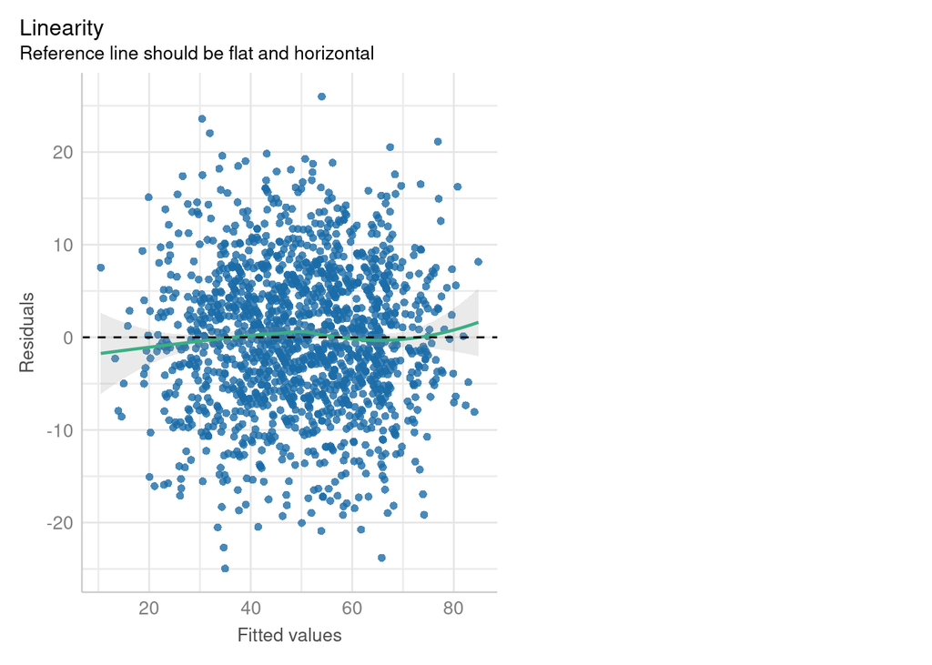

Figure 7

```r
linearity_assumption
```

According to Figure 7 the reference line almost aligns with the flat and horizontal line. This result can confirm that the assumption of linearity was met in this multilevel model.

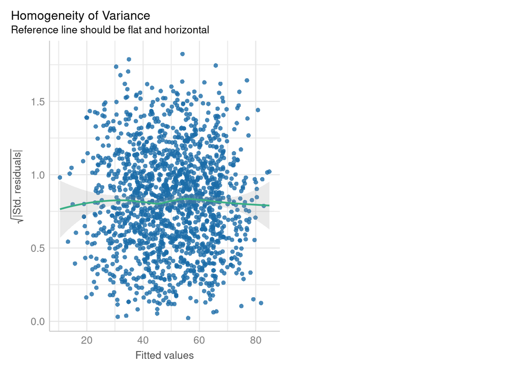

Figure 8

```r
homogeneity_assumption
```

To meet the homoscedasticity assumption, dots in the Figure 8 which shows standardized residuals (y-axis) in the length of fitted values (x-axis) should be like a rectangle to show consistency. According to Figure 8 , the variances of standardized residuals are almost consistent across different levels of fitted values. Also, the line aligns with the horizontal line and no funnel shaped pattern can be seen in this scatter plot.

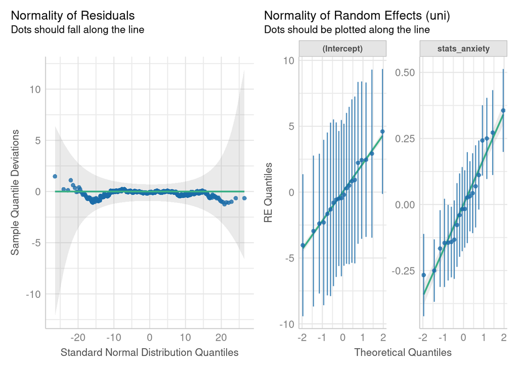

Figure 9

```r
normality_assumption
```

For the assumption of normality in multilevel models, two levels of normality should be met including 1) normality in the distribution of first-level errors of the model and 2) normality in the distribution of random effects (intercept and slope for statistics anxiety (`stats_anxiety`) in this case). In Figure 9 , three q-q plots are provided, one for the normality of first-level errors of the model, one for the normality intercept as a random effect, and one for the slope of the relationship between statistics anxiety (`stats_anxiety`) and students’ performance (`stats_exam`) as a random effect. To meet the assumption of normality dots should fall along the illustrated lines. In all three lines, dots are almost following the horizontal or diagonal lines (even though small deviations might be seen, multilevel models are not sensitive to small deviations). Therefore, the assumption of normality is met in the multilevel model which was fitted.

Overall, all assumptions are met for the fitted multilevel model, hence there is no issue for its implementation and generalizablity, and there is no need for fitting a robust model.

## Statistical models

```r
f_value_model
```

Table 5

|  | Sum Sq | Mean Sq | NumDF | DenDF | F value | Pr(>F) |
| --- | --- | --- | --- | --- | --- | --- |
| gen_anxiety | 7612.586 | 7612.586 | 1 | 1548.017 | 124.438 | 0.000 |
| stats_anxiety | 3916.212 | 3916.212 | 1 | 20.211 | 64.016 | 0.000 |
| community | 150.987 | 75.494 | 2 | 1534.997 | 1.234 | 0.291 |
| stats_anxiety:community | 3927.462 | 1963.731 | 2 | 1537.735 | 32.100 | 0.000 |

To assess the overall significance of predictors in the model (the variance in the model explained by predictors), the ANOVA test with type 3 sum of squares and $F-tests$ was utilized. As is seen in Table 5 , the effect of community (`community`) is not significant, $F(2,1534.99)=1.23,p=0.291$. However, there is a significant effect of general anxiety (`gen_anxiety`), $F(1,1548.01)=124.43,p<0.001$. Also, there is a significant effect of statistics anxiety (`stats_anxiety`), $F(1,20.21)=64.01,p<0.001$. By adding general anxiety to the model, the variance in the model which is explained by general anxiety will be allocated to the general anxiety and won’t be allocated to statistics anxiety (which is a near concept). Hence, by adjusting the model for general anxiety, statistics anxiety can significantly predict the variations in students’ performance on their statistics exam (`stats_exam`). Also, the effect of the interaction between statistics anxiety (`stats_anxiety`) and the community to which students were assigned (`community`) is significant, $F(2,1537.73)=32.1,p<0.001$. According to this, the relationship between statistics anxiety and students’ performance is moderated by the community to which they were assigned. The main effects of statistics anxiety (`stats_anxiety`), general anxiety (`gen_anxiety`), and community group (`community`) are not interpretable in the presence of the significant interaction effect between statistics anxiety and students’ performance. However, ANOVA analysis only provides primary information regarding whether predictors can significantly explain the variability in the fitted model. To find parameter estimates and the direction of effects there is a need to do further parameter estimates analysis.

The provided results in Table 5 are in line with the two first hypotheses introduced as researchers’ hypotheses including 1) Adjusting for general levels of anxiety (`gen_anxiety`), performance on the statistics assignment (`stats_exam`) will be predicted by statistics anxiety (`stats_anxiety`) and 2) the relationship between statistics anxiety and students’ performance will be moderated by the community to which the student was assigned (`community`). However, analyzing the parameter estimates (beta estimations and confidence intervals are necessary to approve them).

```r
fixed_effect_estimates
```

Table 6

| effect | term | estimate | std.error | statistic | df | p.value | conf.low | conf.high |
| --- | --- | --- | --- | --- | --- | --- | --- | --- |
| fixed | (Intercept) | 54.766 | 1.845 | 29.679 | 52.415 | 0.000 | 51.064 | 58.468 |
| fixed | gen_anxiety | 0.316 | 0.028 | 11.155 | 1548.017 | 0.000 | 0.261 | 0.372 |
| fixed | stats_anxiety | -0.420 | 0.052 | -8.001 | 20.211 | 0.000 | -0.529 | -0.310 |
| fixed | communitycommunity_vs_none | 3.843 | 2.461 | 1.561 | 1546.822 | 0.119 | -0.985 | 8.671 |
| fixed | communityinperson_vs_online | -0.392 | 2.896 | -0.135 | 1523.706 | 0.892 | -6.073 | 5.290 |
| fixed | stats_anxiety:communitycommunity_vs_none | 0.390 | 0.061 | 6.430 | 1547.074 | 0.000 | 0.271 | 0.510 |
| fixed | stats_anxiety:communityinperson_vs_online | 0.353 | 0.072 | 4.933 | 1528.773 | 0.000 | 0.213 | 0.493 |

After fitting the multilevel model, two groups of results will be provided including fixed effects and random effects. The provided Table 6 , illustrates parameter estimates for fixed effects after fitting the multilevel model. As is presented, the effect of general anxiety (`gen_anxiety`) as a covariate on the student’s performance is significant and positive, $\beta=0.31[0.26,0.37],t=11.15,p<0.001$. This result means that with other variables being constant, one unit increase in general anxiety among students can increase their score on the statistics exam (`stats_exam`) by $0.31$ of a unit. Considering the interquartile range for general anxiety in the Figure 1 , this result is significant since $10$ point increase in students’ general anxiety can increase their performance by $3.3$ points. Regarding the confidence intervals of this estimate, if this sample is one of the $95\%$ for which the confidence intervals contain the population value then the influence of one unit increase in the general anxiety on the increment of students’ performance can be as small as $0.26$ or as big as $0.37$ of a unit.

According to the aforementioned results, adjusting for general anxiety (gen_anxiety), statistics anxiety (`stats_anxiety`) demonstrates a significant relationship with students’ performance (`stats_exam`). However, as mentioned before, since there is a significant interaction effect between statistics anxiety and community (`community`) which students’ were assigned, interpreting statistics anxiety individually is not possible and it should be interpreted according to the moderator variable (`community`).

According to the mentioned results, the third part of the hypothesis was approved which was Being in a learning community should reduce the relationship between statistics anxiety and statistics performance. Specifically, the relationship between statistics anxiety and statistics performance will be weaker in (1) those assigned to a peer community compared to those not; (2) those assigned to an in-person communities compared to those assigned to an online community.

```r
simple_slopes_tib
```

Table 7

| community | Coefficient | SE | CI | CI_low | CI_high | t | df_error | p |
| --- | --- | --- | --- | --- | --- | --- | --- | --- |
| None | -0.680 | 0.066 | 0.95 | -0.814 | -0.546 | -10.245 | 45.143 | 0.000 |
| Online | -0.466 | 0.067 | 0.95 | -0.600 | -0.332 | -6.994 | 45.170 | 0.000 |
| In person | -0.113 | 0.068 | 0.95 | -0.250 | 0.023 | -1.669 | 49.263 | 0.101 |

Since the interaction effect between statistics anxiety (`stats_anxiety`) and community (`community`) is significant, simple slopes are provided in Table 7 to find the relationship between statistics anxiety and students’ performance on their statistics exam (`stats_exam`) in different levels of community groups (none, online, in-person).

For students who were assigned to no group the relationship between statistics anxiety (`stats_anxiety`) and students’ performance on their statistics exam (`stats_exam`) was negative and significant, $\beta=-0.68[-0.81,-0.55],t=-10.25,p<0.001$. For students who were assigned to online groups this relationship was smaller but still negative and significant, $\beta=-0.47[-0.60,-0.33],t=-6.99,p<0.001$. This results show that while being in online group reduced the impact of statistics anxiety on students’ performance, it could not protect students completely. However, for students who were assigned to in-person groups, this relationship was negative but not significant, $\beta=-0.11[-0.25,0.02],t=-1.67,p=0.101$. This result combined with Figure 4 , demonstrates that being in in-person groups can play the role of a shield that protects students’ performance from being affected by their statistics anxiety levels.

Overall, $10$ point increase in the statistics anxiety (`stats_anxiety`) can decrease students’ performance by $6.8$, $4.7$, and $1.1$ units for students in no group, online groups, and in-person groups, respectively.

```r
random_effect_estimates
```

Table 8

| effect | group | term | estimate | conf.low | conf.high |
| --- | --- | --- | --- | --- | --- |
| ran_pars | uni | sd__(Intercept) | 3.719 | NA | NA |
| ran_pars | uni | cor__(Intercept).stats_anxiety | -0.227 | NA | NA |
| ran_pars | uni | sd__stats_anxiety | 0.192 | NA | NA |
| ran_pars | Residual | sd__Observation | 7.821 | NA | NA |

For the relationship between statistics anxiety (`stats_anxiety`) and students’ performance (`stats_exam`) adjusting for general levels of anxiety with the moderating role of the community to which students were assigned, intercepts and the slopes are shown to vary across 20 universities ( Figure 6 ). So, the intercept and the slope for the for the relationship between statistics anxiety and students’ performance should be treated as random effects instead of fixed effects.

Overall, these results align with the results and our conclusions from Figure 6 , and show that assuming the data as hierarchical data and fitting a multilevel model (MLM) instead of an ordinary least squares model (OLS) was reasonable. Also, it showed that the aforementioned results regarding the $F-statistics$ and parameter estimation from the fitted multilevel model are valid.

```r
comparing_multilevel_models
```

Table 9

|  | npar | AIC | BIC | logLik | deviance | Chisq | Df | Pr(>Chisq) |
| --- | --- | --- | --- | --- | --- | --- | --- | --- |
| final_random_model_intercept_only | 9 | 11094.99 | 11143.26 | -5538.496 | 11076.99 | NA | NA | NA |
| final_random_model | 11 | 11064.08 | 11123.07 | -5521.042 | 11042.08 | 34.909 | 2 | 0 |

To check which model is a better fit for our data, two models including a model assuming intercepts as random effect only, and a model assuming intercepts and slopes as random effect were compared. According to Table 9 , the model with both intercepts and slopes as random effects can explain the relationship with statistics anxiety (`stats_anxiety`) and students’ performance (`stats_exam`) better, $p<00.1$.

## Summary

To sum up, according to the researchers’ hypothesis, levels of students’ performance on their statistics exam (`stats_exam`) (intercepts), and the relationship between statistics anxiety and students’ performance (`stats_exam`) (slopes) vary across 20 universities. By looking at the distribution of intercepts and slopes in Figure 6 , it is reasonable to assume the effect of these values as random effects instead of fixed values. Also, estimates of the variability of intercepts and slopes were provided in Table 8 . Overall, it is reasonable to assume our data as hierarchical data including 2 levels (student level and university level) and the final hypothesis of researchers was approved. Hence, instead of the OLS model, a multilevel model was fitted for further analysis of the main effects and interaction effects.

After fitting the multilevel model, adjusting for the general levels of anxiety (`gen_anxiety`), statistics anxiety predicted students’ performance on their statistics exam significantly and negatively. However, since there was a significant interaction effect between statistics anxiety and the community (`community`) to which students were assigned, the main effect of statistics anxiety was not interpretable.

Moderation analysis demonstrated that being in any community group reduces the relationship between statistics anxiety (`stats_anxiety`) and students’ performance (`Stats_exam`) compared to being in no community group. Additionally, being in in-person groups reduced this relationship more compared to being in online groups. These results align with hypotheses generated by researchers.

Overall, all $H_0$ hypotheses were rejected, and all $H_1$ hypotheses made by researchers were approved.